[Cancer Systems Biology](https://jiantaoshi.github.io/index.html)

[Publications](https://jiantaoshi.github.io/Publications.html) [Software](https://jiantaoshi.github.io/Software.html) [Patents](https://jiantaoshi.github.io/Patents.html) [People](https://jiantaoshi.github.io/People.html) [Notebook](https://jiantaoshi.github.io/Notebook.html) [Careers](https://jiantaoshi.github.io/Careers.html)

# Pairwise sequence alignment

## Retrieving sequences

DNA sequences could be retrieved from NCBI or [ucsc genome browser](https://genome.ucsc.edu/). Another extremely important manually curated database is UniProt, which focuses on protein sequences.

### UniProt

UniProt aims to contains manually curated information on all known protein sequences. For example, you can retrieve the protein sequences for the chorismate lyase protein from Mycobacterium leprae (which has UniProt accession Q9CD83) and for the chorismate lyase protein from Mycobacterium ulcerans (UniProt accession A0PQ23), and save them as FASTA-format files (eg. **Q9CD83.fasta** and **A0PQ23.fasta**).

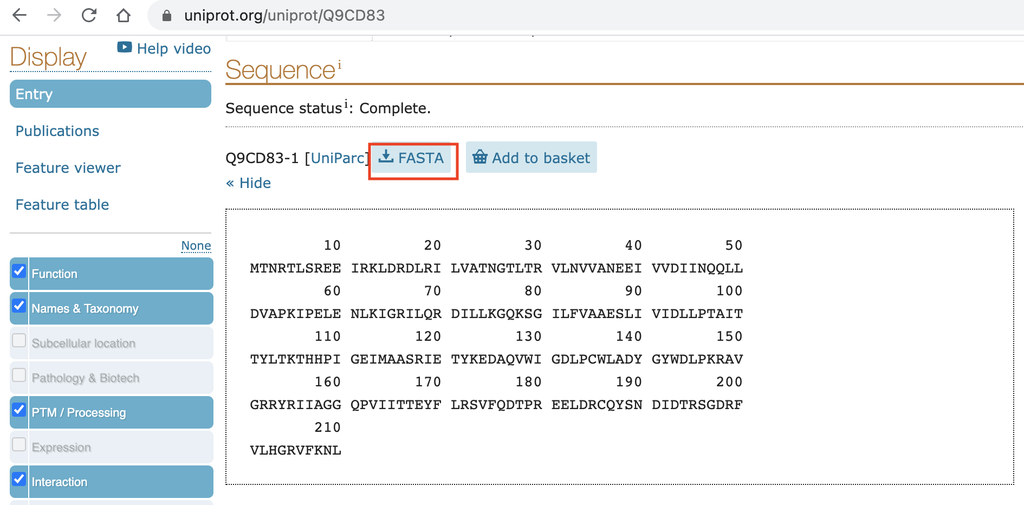

### Loading FASTA sequences

```r
library("seqinr")
leprae <- read.fasta(file = "course/data/Q9CD83.fasta")
ulcerans <- read.fasta(file = "course/data/A0PQ23.fasta")
lepraeseq <- leprae[[1]]
ulceransseq <- ulcerans[[1]]
cat(lepraeseq)
```

```
m t n r t l s r e e i r k l d r d l r i l v a t n g t l t r v l n v v a n e e i v v d i i n q q l l d v a p k i p e l e n l k i g r i l q r d i l l k g q k s g i l f v a a e s l i v i d l l p t a i t t y l t k t h h p i g e i m a a s r i e t y k e d a q v w i g d l p c w l a d y g y w d l p k r a v …
```

## Dot plot

As a first step in comparing two protein, RNA or DNA sequences, it is a good idea to make a dotplot. A dotplot is a graphical method that allows the comparison of two protein or DNA sequences and identify regions of close similarity between them. A dotplot is essentially a two-dimensional matrix (like a grid), which has the sequences of the proteins being compared along the vertical and horizontal axes. In order to make a simple dotplot to represent of the similarity between two sequences, individual cells in the matrix can be shaded black if residues are identical, so that matching sequence segments appear as runs of diagonal lines across the matrix. Identical proteins will have a line exactly on the main diagonal of the dotplot, that spans across the whole matrix. For proteins that are not identical, but share regions of similarity, the dotplot will have shorter lines that may be on the main diagonal, or off the main diagonal of the matrix. In essence, a dotplot will reveal if there are any regions that are clearly very similar in two protein (or DNA) sequences.

### Homologous sequence

Here let’s comapred the homologous sequences of chorismate lyase protein from Mycobacterium leprae (Q9CD83) and Mycobacterium ulcerans (A0PQ23).

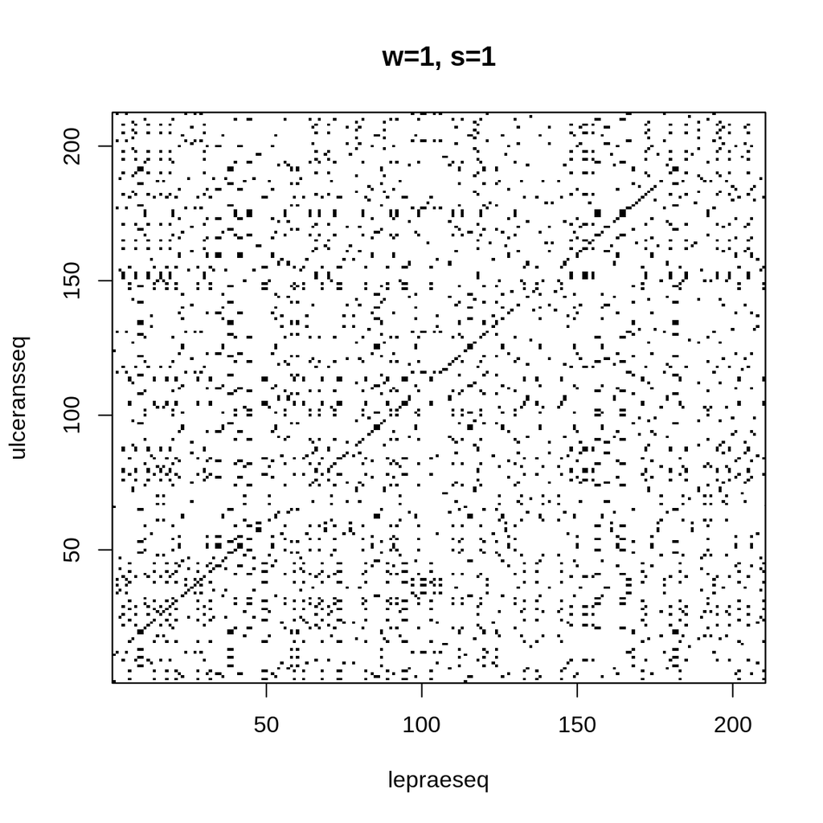

```r
dotPlot(lepraeseq, ulceransseq, wsize = 1, wstep = 1, nmatch = 1, main = "w=1, s=1")
```

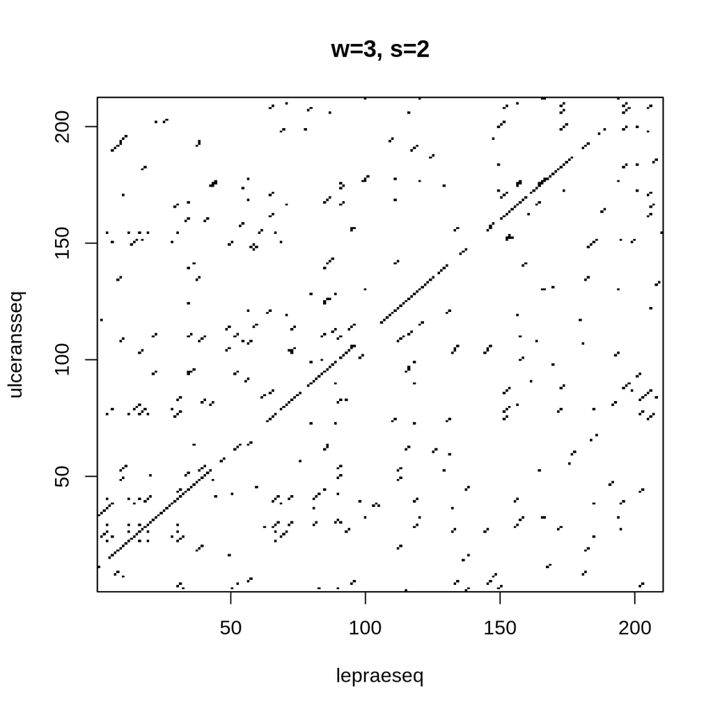

```r
dotPlot(lepraeseq, ulceransseq, wsize = 3, wstep = 1, nmatch = 2, main = "w=3, s=2")
```

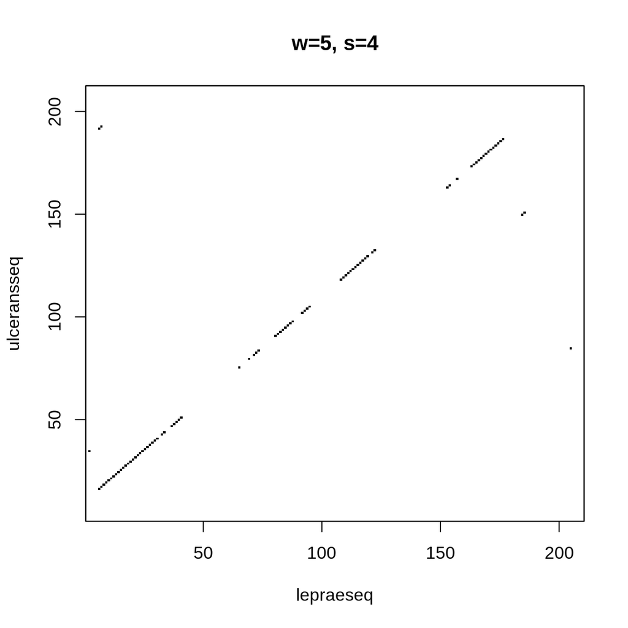

```r
dotPlot(lepraeseq, ulceransseq, wsize = 5, wstep = 1, nmatch = 4, main = "w=5, s=4")
```

### Repeats

We can also use dotPlot to show repeat structure within a sequence. For example, human LDL protein sequence (P01130) contains obvious repeats, and this can be shown easily with dotPlot.

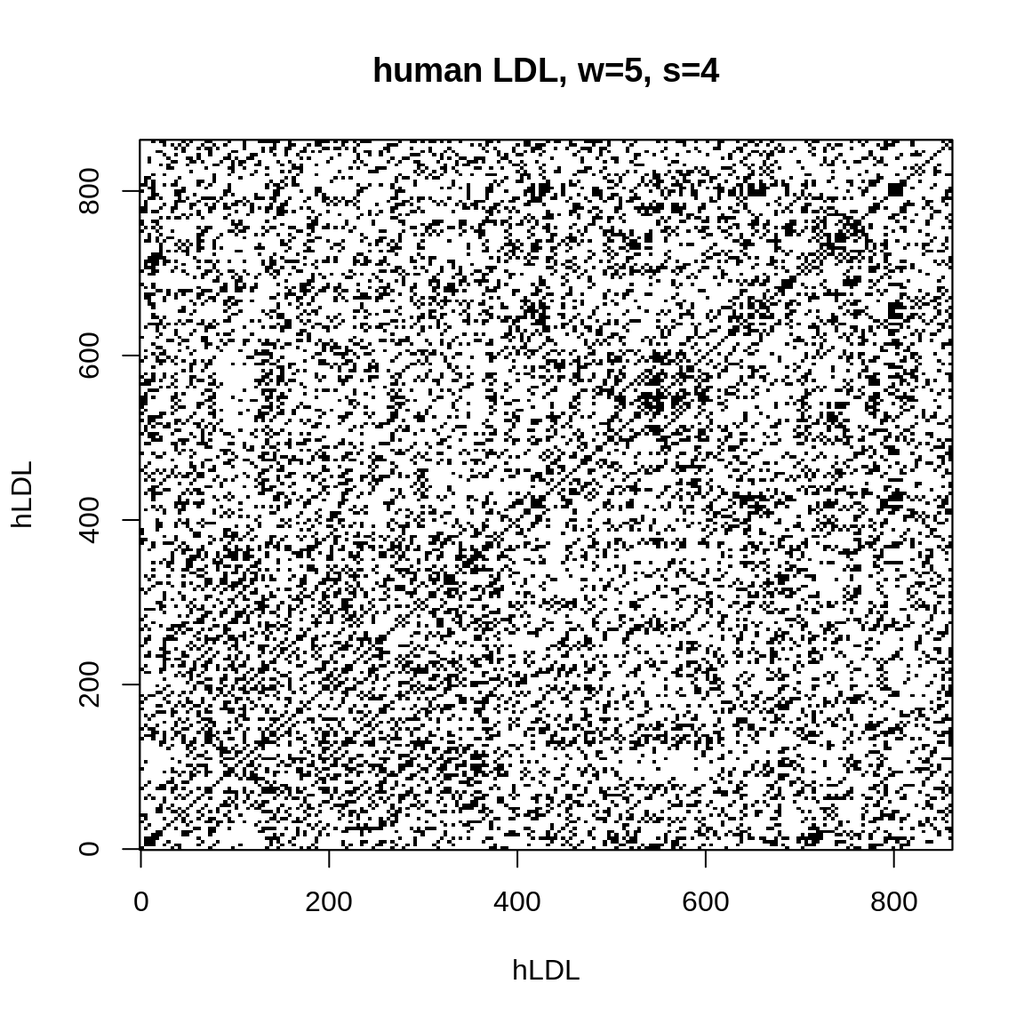

```r
hLDL <- read.fasta(file = "course/data/P01130.fasta")[[1]]
dotPlot(hLDL, hLDL, wsize = 5,  wstep = 4, nmatch = 1, main = "human LDL, w=5, s=4")
```

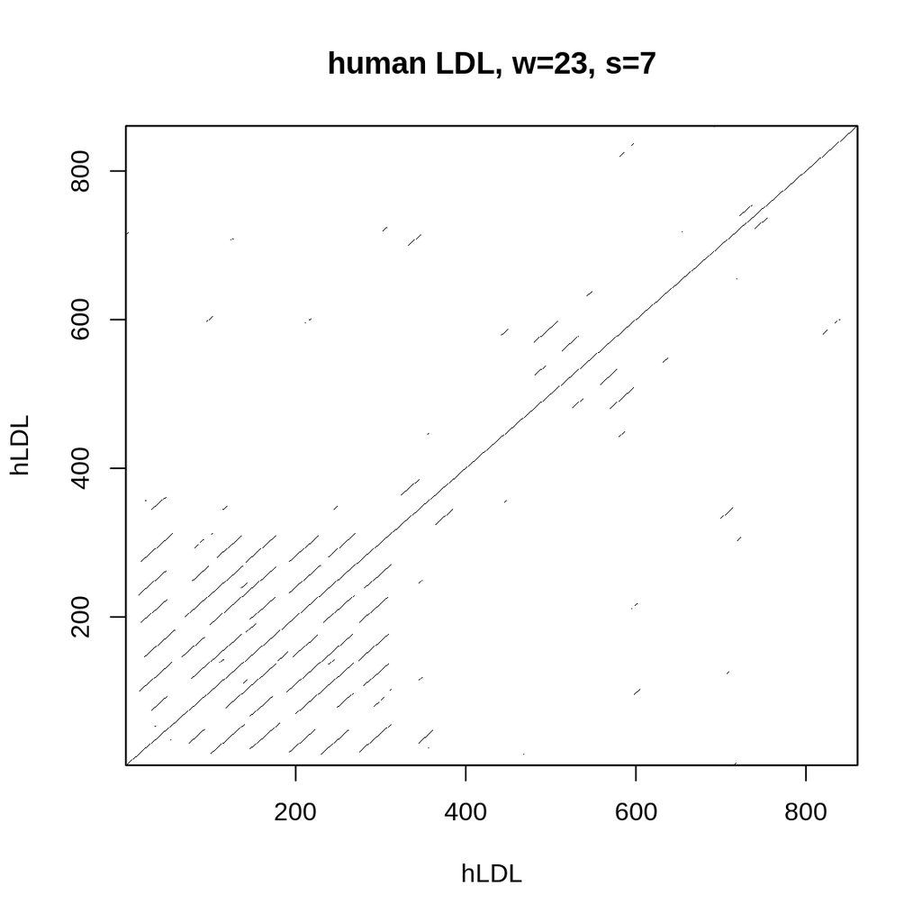

```r
dotPlot(hLDL, hLDL, wsize = 23, wstep = 1, nmatch = 7, main = "human LDL, w=23, s=7")
```

## Global alignment

If you are studying a particular pair of genes or proteins, an important question is to what extent the two sequences are similar. To quantify similarity, it is necessary to align the two sequences, and then you can calculate a similarity score based on the alignment. There are two types of alignment in general. A **global alignment** is an alignment of the full length of two sequences, for example, of two protein sequences or of two DNA sequences. A **local alignment** is an alignment of part of one sequence to part of another sequence.

### Substitution matrix

The first step in computing a alignment (global or local) is to decide on a scoring system, which is also known as a substitution matrix. The scoring matrix has one row and one column for each possible letter in our alphabet of letters (eg. 4 rows and 4 columns for DNA sequences). To make a scoring matrix which assigns a score of +1 to a match and -1 to a mismatch, and store it in the variable sigma, we type:

```r
library(Biostrings)
sigma <- nucleotideSubstitutionMatrix(match = 1, mismatch = -1, baseOnly = TRUE)
sigma
```

```
   A  C  G  T
A  1 -1 -1 -1
C -1  1 -1 -1
G -1 -1  1 -1
T -1 -1 -1  1
```

### The Needleman-Wunsch algorithm

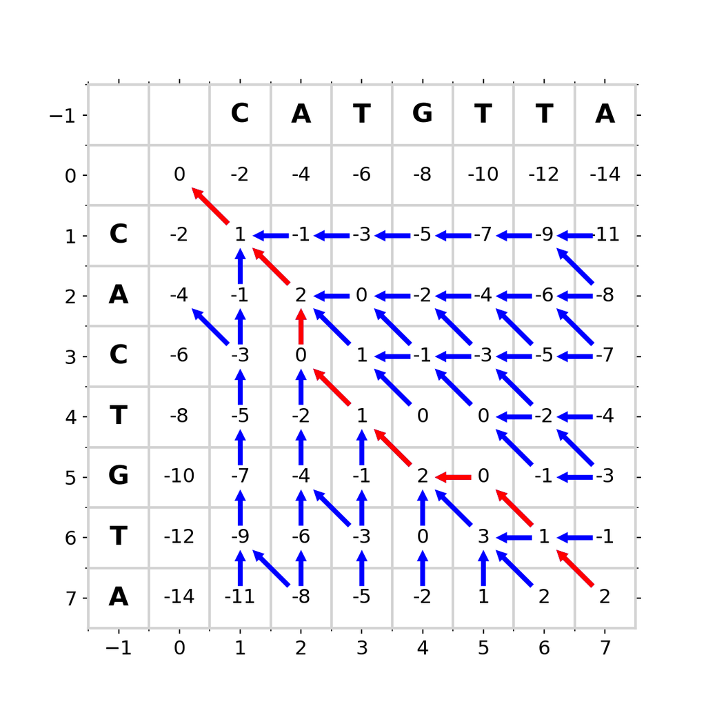

```python
from course.code.plot_nw import *
from course.code.plot_sw import *
seq1 = Seq("CATGTTA")
seq2 = Seq("CACTGTA")
penalty = {'MATCH': 1, 'MISMATCH': -1, 'GAP': -2}
plot_nw(seq1, seq2, penalty, 6, 6)
```

In *Biostrings* package, instead of assigning the same penalty to every gap position, it is common instead to assign a gap opening penalty to the first position in a gap, and a smaller gap extension penalty to every subsequent position in the same gap.

```r
s1 <- "CATGTTA"
s2 <- "CACTGTA"
globalAligns1s2 <- pairwiseAlignment(s1, s2, substitutionMatrix = sigma, gapOpening = -1, gapExtension = -1, scoreOnly = FALSE)
globalAligns1s2
```

```
Global PairwiseAlignmentsSingleSubject (1 of 1)
pattern: CA-TGTTA
subject: CACTGT-A
score: 2
```

### BLOSUM matrices

As well as DNA alignments, it is also possible to make alignments of protein sequences. In this case it is necessary to use a scoring matrix for amino acids rather than for nucleotides. There are several well known scoring matrices that come with R, such as the BLOSUM series of matrices. Different BLOSUM matrices exist, named with different numbers. BLOSUM with high numbers are designed for comparing closely related sequences, while BLOSUM with low numbers are designed for comparing distantly related sequences. For example, BLOSUM62 is used for less divergent alignments (alignments of sequences that differ little), and BLOSUM30 is used for more divergent alignments (alignments of sequences that differ a lot).

```r
data(package="Biostrings")
data(BLOSUM50)
s3 <- "PAWHEAE"
s4 <- "HEAGAWGHEE"
globalAligns3s4 <- pairwiseAlignment(s3, s4, substitutionMatrix = "BLOSUM50", gapOpening = -2, gapExtension = -8, scoreOnly = FALSE)
globalAligns3s4
```

```
Global PairwiseAlignmentsSingleSubject (1 of 1)
pattern: P---AWHEAE
subject: HEAGAWGHEE
score: -5
```

We set “gapOpening” to be -2 and “gapExtension” to be -8, which means that the first position of a gap is assigned a score of (-8-2=)-10, and every subsequent position in a gap is given a score of -8. This means that the gap will be given a score of -10-8-8 = -26.

## Local alignment

You can use the pairwiseAlignment() function to find the optimal local alignment of two sequences, that is the best alignment of parts (subsequences) of those sequences, by using the “type=local” argument in pairwiseAlignment(). This uses the **Smith-Waterman algorithm** for local alignment, the classic bioinformatics algorithm for finding optimal local alignments.

```
## (6, 5)
```

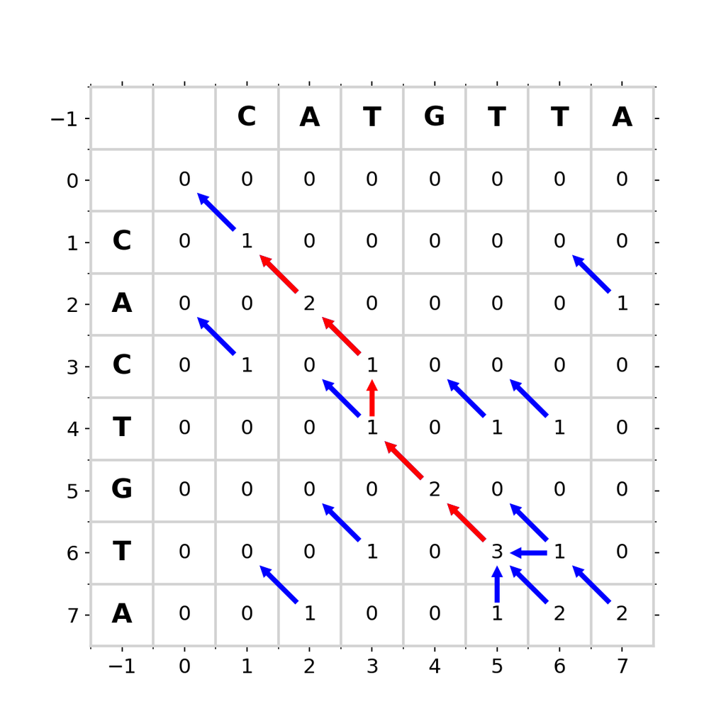

```python
seq1 = Seq("CATGTTA")
seq2 = Seq("CACTGTA")
penalty = {'MATCH': 1, 'MISMATCH': -1, 'GAP': -2}
plot_sw(seq1, seq2, penalty, 6, 6)
```

```r
s1 <- "CATGTTA"
s2 <- "CACTGTA"
globalAligns1s2 <- pairwiseAlignment(s1, s2, substitutionMatrix = sigma, gapOpening = -1, gapExtension = -1, scoreOnly = FALSE, type="local")
globalAligns1s2
```

```
Local PairwiseAlignmentsSingleSubject (1 of 1)
pattern: [1] CA-TGT
subject: [1] CACTGT
score: 3
```

## Acknowledgements

This document was rewritten base on a chapter from [a little book of R for bioinformatics](https://a-little-book-of-r-for-bioinformatics.readthedocs.io/en/latest/src/chapter4.html) and licensed under a [Creative Commons Attribution 3.0 License](http://creativecommons.org/licenses/by/3.0/). Python function for plotting Needleman-Wunsch and Smith-Waterman algorithms were downloaded from github.

Shanghai Institute of Biochemistry and Cell Biology, Center for Excellence in Molecular Cell Science, CAS